# Ejercicio_1

Patricio Guledjian, Azul Noguera, Rocio Gonzalez

2023-08-20

1. Indique precisamente de dónde se obtuvieron los datos.

Obtuvimos los datos de la siguiente pagina: https://archive.ics.uci.edu/dataset/186/wine+quality y utilizamos el csv de vinos blancos.

2. Presente las características principales del conjunto de datos (e.g., cantidad de observaciones, cantidad de variables, tipo de variables, presencia de valores faltantes).
- Cantidad de observaciones: 4898
- Cantidad de variables: 12
- Tipo de variables: Numericas
- Presencia de valores faltantes: No
3. Explique qué es lo que se intentará predecir.

Lo que intentaremos predecir a partir de nuestras variables predictoras es si la calidad del vino es buena, donde el valor 1 representa que un vino es de buena calidad, y 0 si no lo es. Esta predicción no es trivial debido a que las variables que se usan para predecir no solo son dificiles de interpretar individualmente, sino que ademas las distintas variables pueden interactuar de manera compleja entre si.

4. Haga todas las transformaciones a los datos requeridas.

Como la variable a predecir del dataset descargado no era de clasificación binaria, tuvimos que modificar nuestro dataset. El dataset contenía una columna llamada ‘quality’ en donde se representaba la calidad del vino con un numero entre 1 (vino de peor calidad) y 10 (vino de mejor calidad). Por lo tanto, decidimos adaptar esta variable predictora a una que se ajuste a nuestro problema de clasificación binaria. Para ello, calculamos la mediana, el promedio, e hicimos un histograma entre todos los valores de ‘quality’ de nuestras 4898 instancias, para poder visualizar la cantidad de apariciones de cada valor y decidir el punto de corte entre un vino de buena calidad y uno de mala calidad, intentando repartir de manera equitativa los datos.

```r
datos <- read.csv("./data/winequality-white.csv", sep = ';')

median(datos$quality)
```

```
## [1] 6
```

```r
mean(datos$quality)
```

```
## [1] 5.877909
```

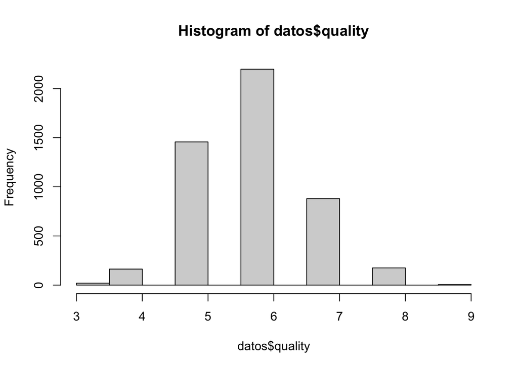

```r
hist(datos$quality)
```

A partir de estos resultados, consideramos que el valor 6 es un buen punto de corte para nuestra clasificación binaria.

```r
# Cargar el archivo CSV en un DataFrame
datos <- read.csv("./data/winequality-white.csv", sep = ';')

head(datos$quality, n = 20)
```

```
##  [1] 6 6 6 6 6 6 6 6 6 6 5 5 5 7 5 7 6 8 6 5
```

```r
# Recorrer la columna y modificar los valores
for (i in 1:length(datos$quality)) {
  if (datos$quality[i] >= 6) {
    datos$quality[i] <- 1
  } else {
    datos$quality[i] <- 0
  }
}

ruta_archivo_nuevo <- "./data/winequality_modificados.csv"
write.csv(datos, file=ruta_archivo_nuevo, sep = ',', row.names=FALSE)
head(datos$quality, n = 20)
```

```
##  [1] 1 1 1 1 1 1 1 1 1 1 0 0 0 1 0 1 1 1 1 0
```

Podemos ver como los valores mayores o iguales a 6 fueron reemplazados por un 1, y los valores menores a 6 por un 0.

5. Guarde el archivo a analizar en formato CSV tradicional (texto plano delimitado por comas, en donde la primera fila debe contener los nombres de las variables).

Nuestro dataset no vino en formato tradicional ya que el separador usado era ‘;’. De todas maneras, al modificar la columna como hicimos en el ultimo código, aprovechamos para escribir el nuevo csv con separador ‘,’. Luego de eso, el dataset quedo en formato tradicional.

```r
head(datos, n = 10)
```

```
##    fixed.acidity volatile.acidity citric.acid residual.sugar chlorides
## 1            7.0             0.27        0.36           20.7     0.045
## 2            6.3             0.30        0.34            1.6     0.049
## 3            8.1             0.28        0.40            6.9     0.050
## 4            7.2             0.23        0.32            8.5     0.058
## 5            7.2             0.23        0.32            8.5     0.058
## 6            8.1             0.28        0.40            6.9     0.050
## 7            6.2             0.32        0.16            7.0     0.045
## 8            7.0             0.27        0.36           20.7     0.045
## 9            6.3             0.30        0.34            1.6     0.049
## 10           8.1             0.22        0.43            1.5     0.044
##    free.sulfur.dioxide total.sulfur.dioxide density   pH sulphates alcohol
## 1                   45                  170  1.0010 3.00      0.45     8.8
## 2                   14                  132  0.9940 3.30      0.49     9.5
## 3                   30                   97  0.9951 3.26      0.44    10.1
```

[output cut: 18 more lines]